# **Project -**

# **Static Files**

- [ First download the template from https://startbootstrap.com/themes and https://colorlib.com/ ]

first goto the folder and copy the .html file into the template and then copy the js css and assets other files into the startapp folder

- [

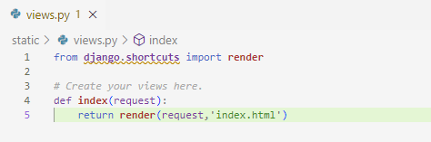

  ]
- first goto the urls in static
- [

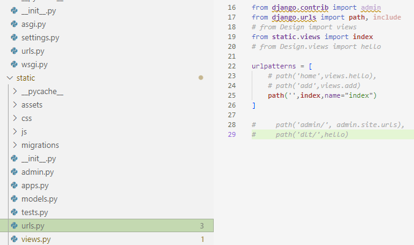

  ]
- goto the urls in DTL
- [

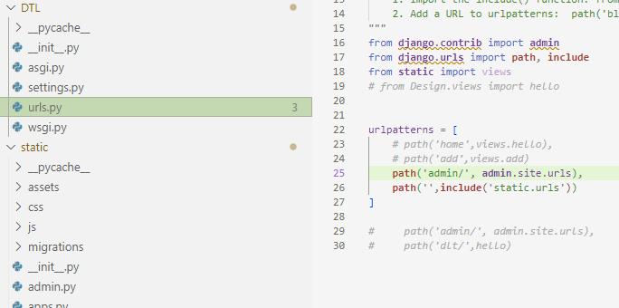

  ]
- then goto the settings
- [

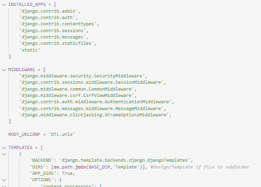

  ]  
  [

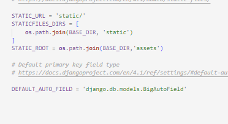

  ]
- In html file
- [

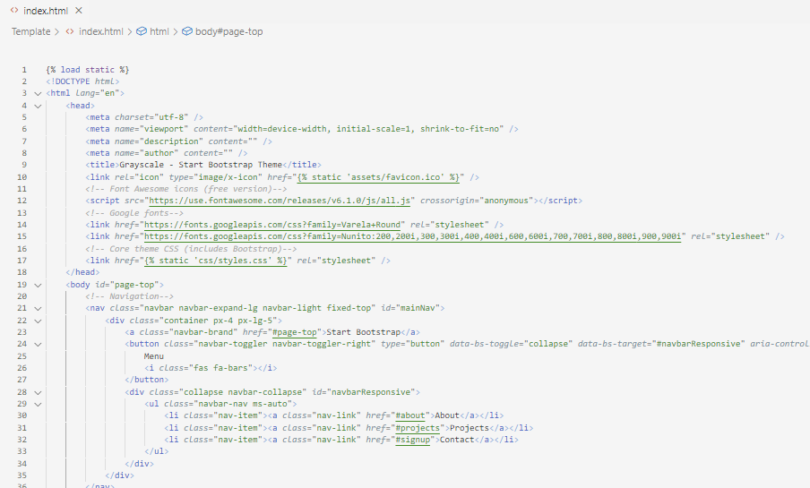

  ]
- [

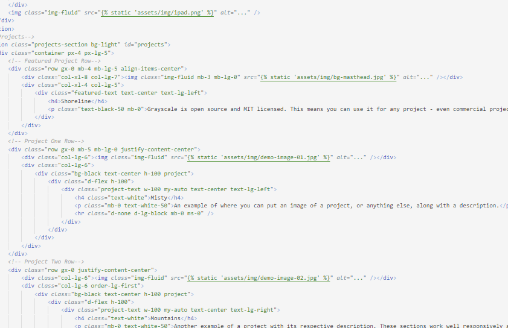

  ]
- [

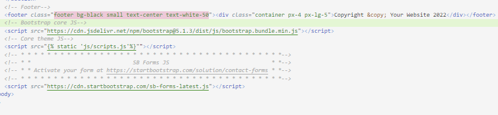

  ]

# **User-Registeration And Login redirect**

- []
- [

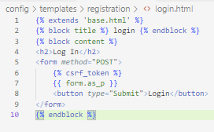

  ]
- []
- [

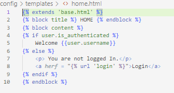

  ]
- []
- [

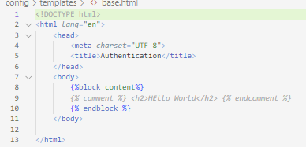

  ]
- []
- [

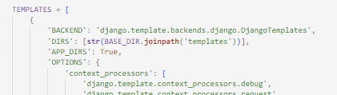

  ]
- []
- []
- []
- [

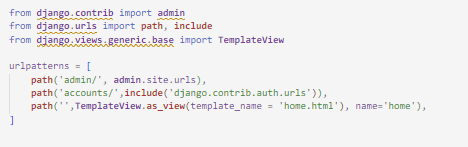

  ]
- []
- Normalised Function

# **LOGOUT FORMAT**

- [

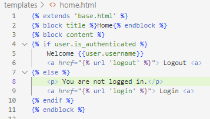

  ]
- []
- [

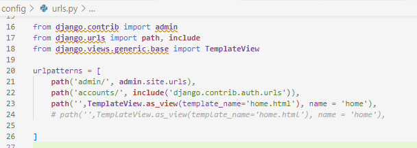

  ]
- []
- [

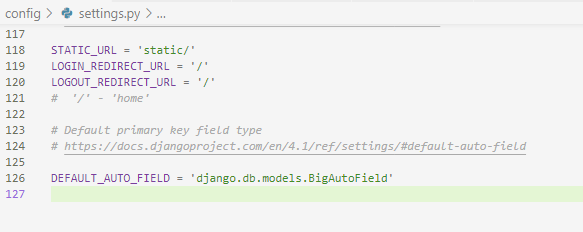

  ]
- []
- [

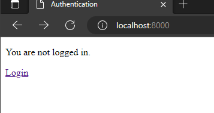

  ]
- []
- [

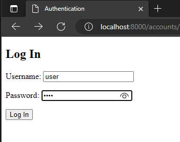

  ]
- []
- [

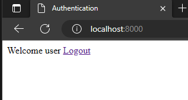

  ]

# **FORMS WEB/WEBapp**

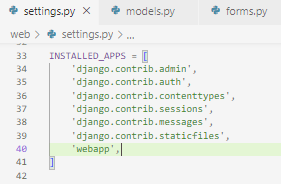

- []
- []

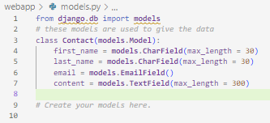

- []
- []
- [

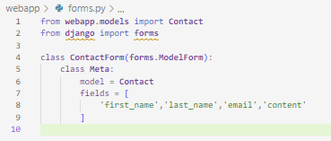

  ]
- []
- [

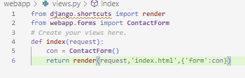

  ]
- []
- []
- []
- [

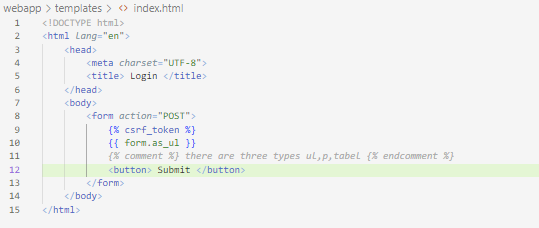

  ]
- []
- [

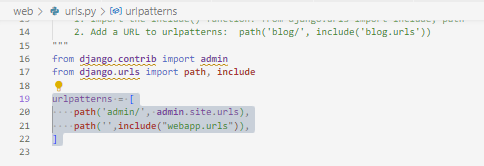

  ]
- []
- [

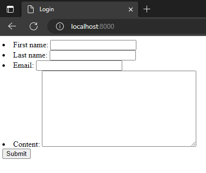

  ]

# pip install django-crispy-forms

- [

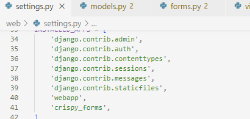

  ]
- [

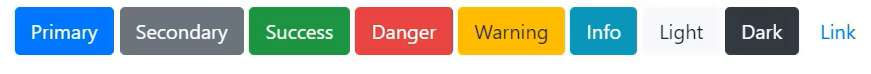

  ]
- [these format we can use in our projects from this sites https://getbootstrap.com/docs/4.1/getting-started/introduction/ ]
- [

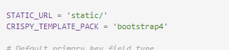

  ]
- []
- [

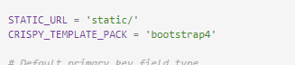

  ]
- []
- [

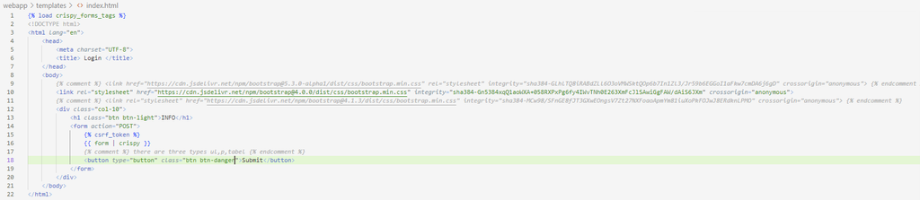

  ]
- []
- [

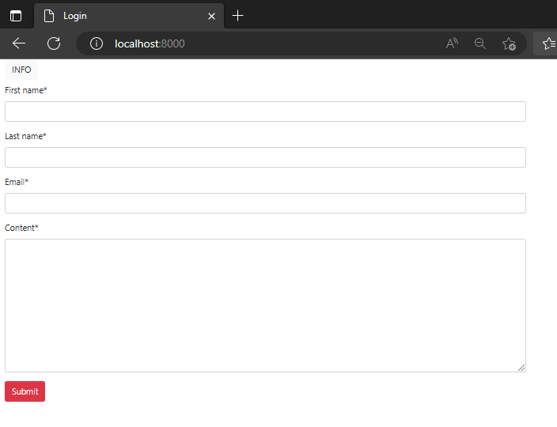

  ]

# **CREATING YOUR OWN BLOG**

First create the project and then

- [

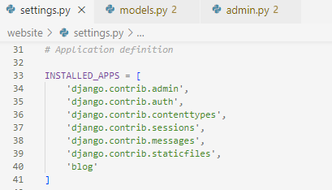

  ]
- []
- [

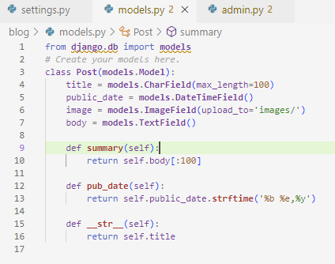

  ]
- []
- [

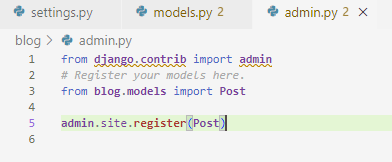

  ]
- []
- [

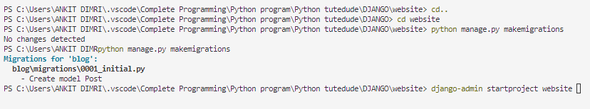

  ]
- []
- [

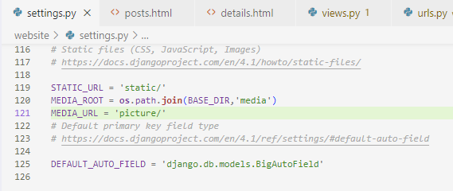

  ]
- [

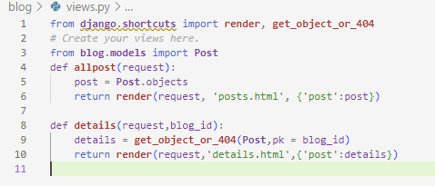

  ]
- []
- [

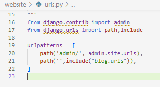

  ]
- []
- [

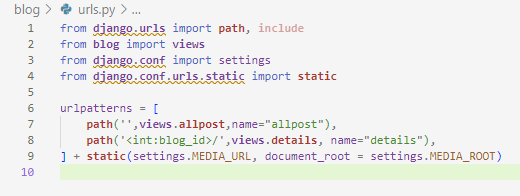

  ]
- []
- [

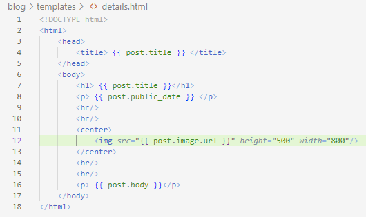

  ]
- []
- [

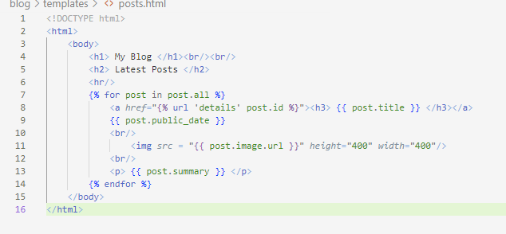

  ]
- []
- [

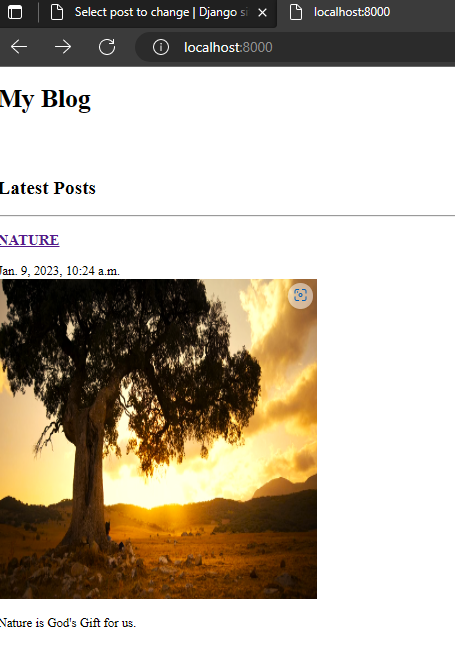

  ]
- []
- [

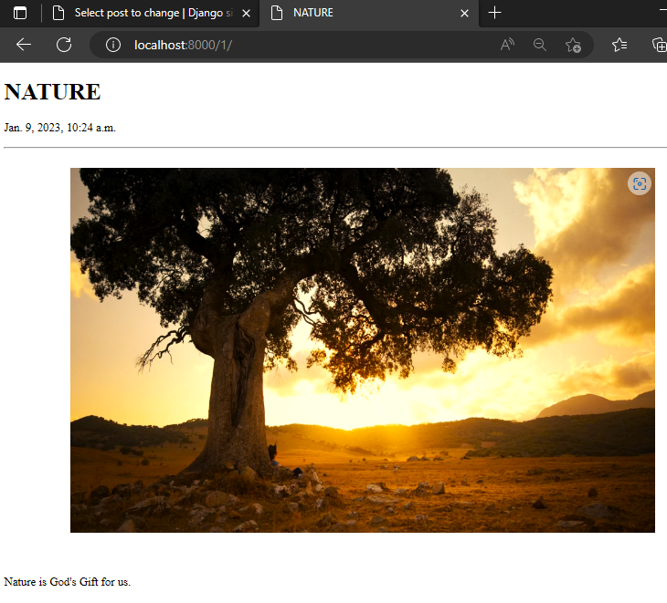

  ]

### --------------------------Complete--------------------------------